# Music Listening Habits

## Did listening time change a lot depending on the time of day?

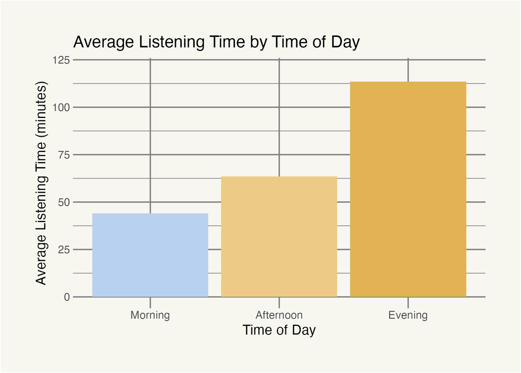

Average listening time was greatest in the evening. This was quite a significant difference compared with the morning and afternoon. This makes sense because I often study and do art in the evenings when I don’t have lectures, and these are activities where I usually listen to music for longer periods.

## Does my listening time differ much depending on what I am doing?

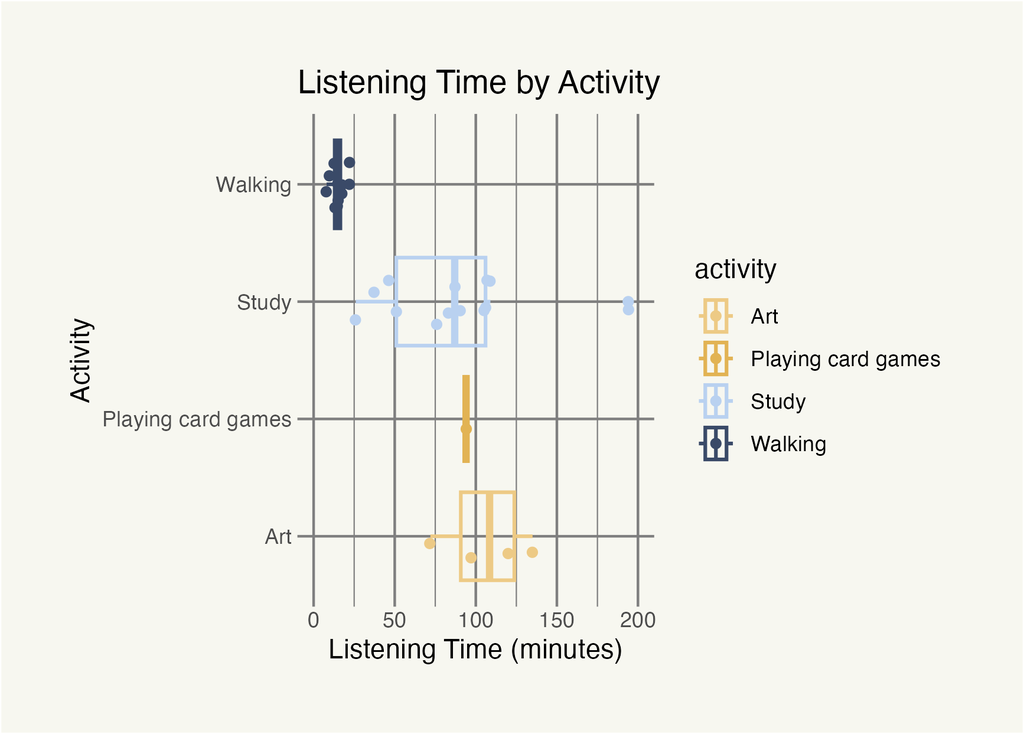

## Is there a day I often listen to music more?

[figure not shown]

Column plot of average listening time by day of week. Saturday has the highest listening time and Monday and Friday have the lowest.

It looks like a lot of days are pretty similar in terms of average listening time; Saturday is the day I listen to music the most. This makes sense, since Saturday is part of the weekend, so I usually have more free time to study, paint, or do other craft activities. Monday and Friday have the lowest average listening times suggest my listening habbits are lower around the start and end of working week

## In conclusion

The data suggests that my listening time is highest during studying and doing art activities, with Saturdays showing the greatest average listening time overall for the week.

[figure not shown]